# R Notebook

## Proper Data Format in ggplot2

```r
require(ggplot2)
require(caret)
```

## Plotting multiple variables

Instead of doing a duplicated point call to overplot a plot with 4 variables…

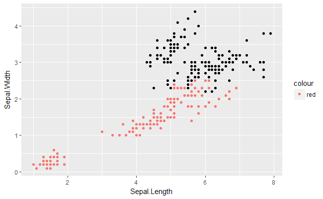

```r
ggplot(iris, aes(Sepal.Length, Sepal.Width)) +
  geom_point() +
  geom_point(aes(Petal.Length, Petal.Width, col="red"))
```

Which still does not display a correct legend to the dataset.. We need to keep the standard ggplot call:

- Taking three variables (Length, Width and LeafType)
- and plot them onto three dimensions(x,y,colour)

For this procedure to work, we first need to arrange the data accordingly

```r
require(tidyr)
# Cleaning the dataset
iris.tidy <- iris %>%
      gather(key, Value, -Species) %>%
      separate(key, c("Part", "Measure"), "\\.")
# Inspecting the dataset
str(iris.tidy)
```

```
'data.frame':   600 obs. of  4 variables:
 $ Species: Factor w/ 3 levels "setosa","versicolor",..: 1 1 1 1 1 1 1 1 1 1 ...
 $ Part   : chr  "Sepal" "Sepal" "Sepal" "Sepal" ...
 $ Measure: chr  "Length" "Length" "Length" "Length" ...
 $ Value  : num  5.1 4.9 4.7 4.6 5 5.4 4.6 5 4.4 4.9 ...
```

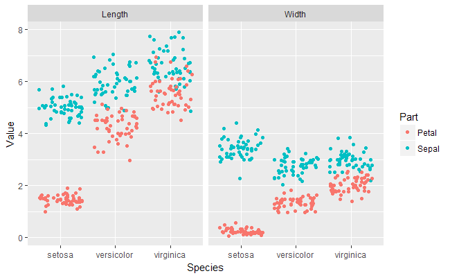

```r
# Drawing the plot
ggplot(iris.tidy, aes(Species, Value, col=Part)) +
  geom_jitter() +
  facet_grid(. ~ Measure)
```

```r
NA
```

Creating different collections for the dataset

```r
head(iris)
```

|  | Sepal.Length | Sepal.Width | Petal.Length | Petal.Width | Species |
| --- | --- | --- | --- | --- | --- |
| 1 | 5.1 | 3.5 | 1.4 | 0.2 | setosa |
| 2 | 4.9 | 3.0 | 1.4 | 0.2 | setosa |
| 3 | 4.7 | 3.2 | 1.3 | 0.2 | setosa |
| 4 | 4.6 | 3.1 | 1.5 | 0.2 | setosa |
| 5 | 5.0 | 3.6 | 1.4 | 0.2 | setosa |
| 6 | 5.4 | 3.9 | 1.7 | 0.4 | setosa |

```r
data("iris")
iris$Flower <- 1:nrow(iris)
# Creating the dataset
iris.wide <- iris %>%
      gather(key, value, -Species, -Flower) %>%
      separate(key, c("Part", "Measure"), "\\.") %>%
      spread(Measure, value)
# inspecting the dataset
str(iris.wide)
```

```
'data.frame':   300 obs. of  5 variables:
 $ Species: Factor w/ 3 levels "setosa","versicolor",..: 1 1 1 1 1 1 1 1 1 1 ...
 $ Flower : int  1 1 2 2 3 3 4 4 5 5 ...
 $ Part   : chr  "Petal" "Sepal" "Petal" "Sepal" ...
 $ Length : num  1.4 5.1 1.4 4.9 1.3 4.7 1.5 4.6 1.4 5 ...
 $ Width  : num  0.2 3.5 0.2 3 0.2 3.2 0.2 3.1 0.2 3.6 ...
```

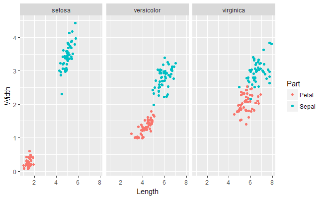

```r
# Plotting Width / Length over Species
ggplot(iris.wide, aes(Length, Width, col=Part)) +
  geom_jitter() +
  facet_grid(.~ Species)
```

```r
# Plotting width/ Length by
str(iris.wide)
```

```
'data.frame':   300 obs. of  5 variables:
 $ Species: Factor w/ 3 levels "setosa","versicolor",..: 1 1 1 1 1 1 1 1 1 1 ...
 $ Flower : int  1 1 2 2 3 3 4 4 5 5 ...
 $ Part   : chr  "Petal" "Sepal" "Petal" "Sepal" ...
 $ Length : num  1.4 5.1 1.4 4.9 1.3 4.7 1.5 4.6 1.4 5 ...
 $ Width  : num  0.2 3.5 0.2 3 0.2 3.2 0.2 3.1 0.2 3.6 ...
```

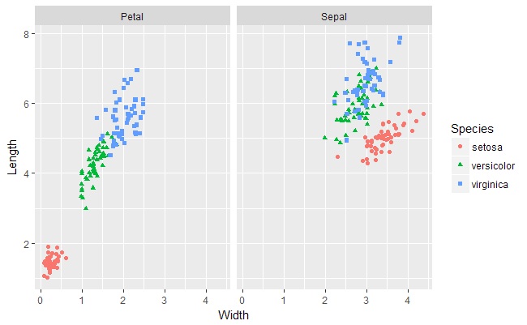

```r
ggplot(iris.wide, aes(Width, Length, shape=Species, col=Species)) +
  geom_jitter() +
  facet_grid(.~ Part)
```

## Exploring Aesthetics

For ggplot 2 these are attributes. These are used what variables are mapped onto what visual astetic qualities

for example : - colour - size -

Modifying Asthethics:

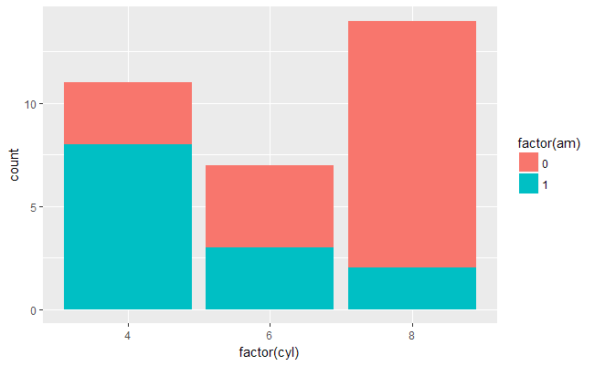

```r
ggplot(mtcars, aes(factor(cyl), fill=factor(am))) +
  geom_bar(stat="count", position="stack")
```

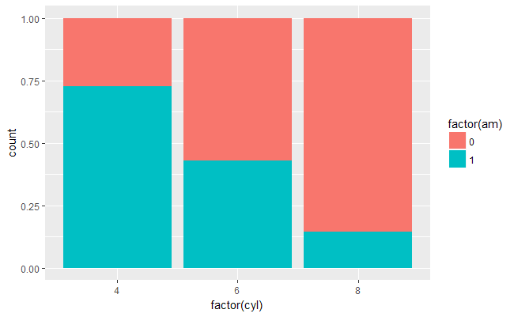

```r
ggplot(mtcars, aes(factor(cyl), fill=factor(am))) +
  geom_bar(stat="count", position="fill")
```

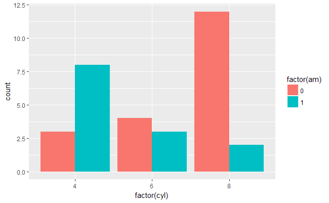

```r
ggplot(mtcars, aes(factor(cyl), fill=factor(am))) +
  geom_bar(stat="count", position="dodge")
```

Setting additional parameters

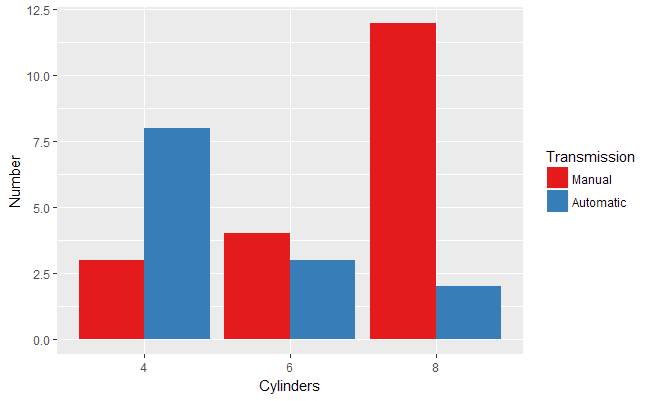

```r
# Setting the values
val = c("#E41A1C", "#377EB8")
lab = c("Manual", "Automatic")
# Drawing the plot
ggplot(mtcars, aes(factor(cyl), fill=factor(am))) +
  geom_bar(stat="count", position="dodge") +
  scale_x_discrete("Cylinders") +
  scale_y_continuous("Number") +
  scale_fill_manual("Transmission", values = val,
                    labels= lab)
```

## Setting a dummy aesthetic

Jitter introduces a random noise with a set sd of 0.2, this is used to artificially set the dots appart so they do not overplot on the same exact plot location.

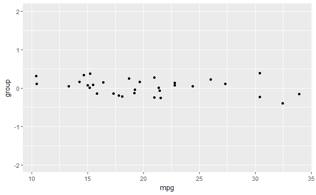

```r
mtcars$group <- 0
# Plot the data against 0
ggplot(mtcars, aes(mpg, group)) +
  geom_jitter() +
  scale_y_continuous(limits = c(-2,2))
```

### Aesthetics best practice

Which one do we choose, but there is clear guidance.

refers to: Jacques Bertin, William Cleveland.

You want to either explore, or to educate and persuade. This is defined based on the appropriate audience for the plotting.

### Aesthetics - Continous Variables

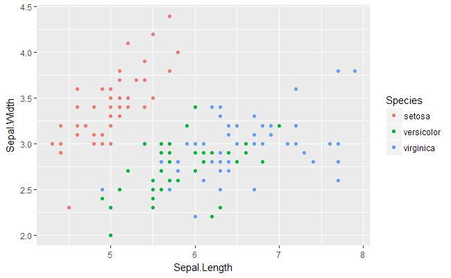

```r
ggplot(iris, aes(Sepal.Length, Sepal.Width, col=Species)) +
  geom_point()
```

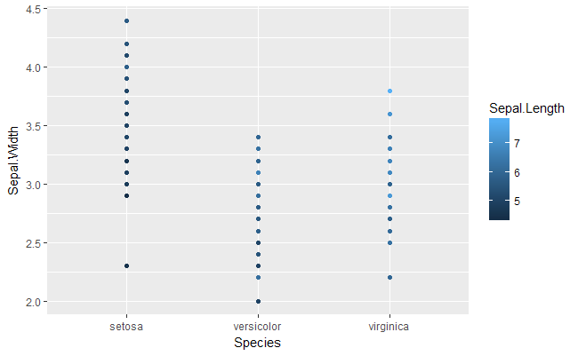

```r
ggplot(iris, aes(Species, Sepal.Width, col=Sepal.Length)) +
  geom_point()
```

Aesthetics include:

- x
- y
- size
- shape
- fill
- colour
- alpha

Definatly avoid:

- unaligned scales
- adding duplicated visual differences (col&shape)

### Overplotting Errors

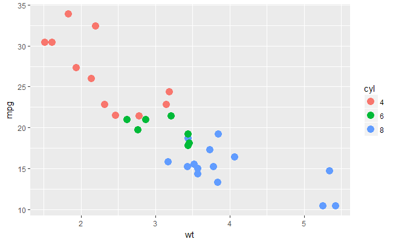

```r
ggplot(mtcars, aes(wt, mpg, col=cyl)) +
  geom_point(size=4)
```

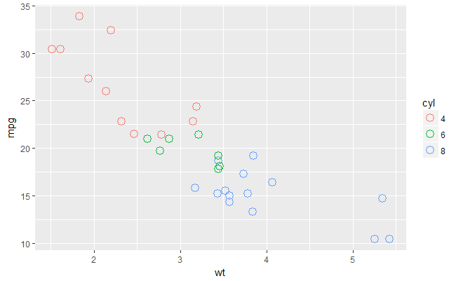

```r
ggplot(mtcars, aes(wt, mpg, col=cyl)) +
  geom_point(shape=1, size=4)
```

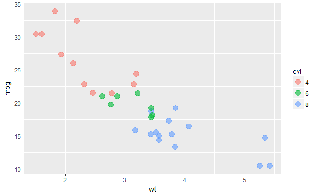

```r
ggplot(mtcars, aes(wt, mpg, col=cyl)) +
  geom_point(alpha=0.6, size=4)
```

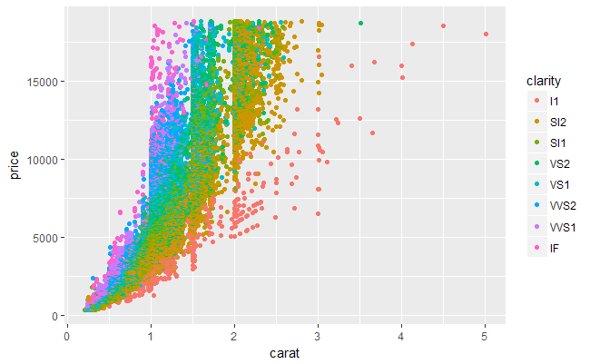

```r
ggplot(diamonds, aes(carat, price, col=clarity)) +
  geom_point()
```

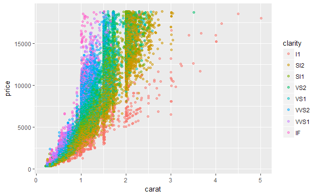

```r
ggplot(diamonds, aes(carat, price, col=clarity)) +
  geom_point(alpha=0.5)
```

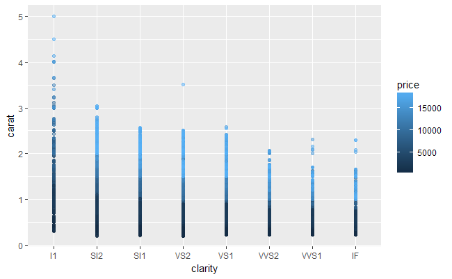

```r
ggplot(diamonds, aes(clarity, carat, col=price)) +
  geom_point(alpha=0.5)
```

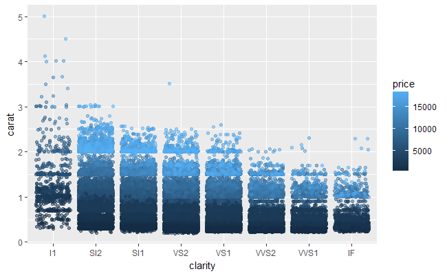

```r
ggplot(diamonds, aes(clarity, carat, col=price)) +
  geom_point(position="jitter", alpha=0.5)
```

### Scatter Plots

Looking at the Geometry layer.

There are currently 37 different options:

- abline
- area
- bar
- bin2d
- blank
- boxplot
- contour
- crossbar
- density
- density2d
- dotplot
- errorbar
- errorbarh
- freqpoly
- hex
- histogram
- hline
- jitter
- line
- linerange
- map
- path
- point
- pointrange
- polygon
- quantile
- raster
- rect
- vline
- ribbon
- rug
- segment
- smooth
- step
- text
- tile
- violin

Lets look at the common plots:

#### Scatter Plot

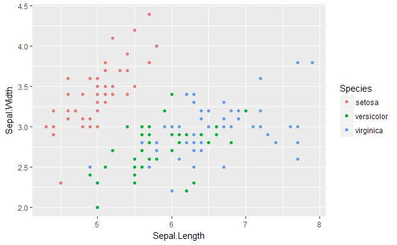

```r
plot1 <- ggplot(iris, aes(Sepal.Length, Sepal.Width)) +
      geom_point(aes(col=Species))
plot1
```

We can assign the data to use inside a function call to the geom.

Here we add the data

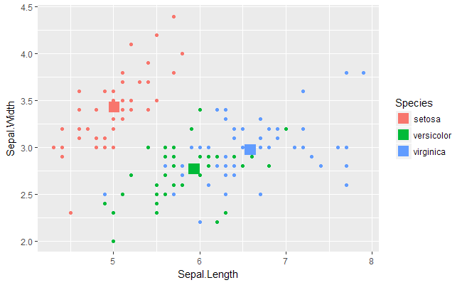

```r
data(iris)
iris.summary <- aggregate(iris[1:4], list(iris$Species), mean)
names(iris.summary)[1] <- "Species"
# Plotting the dataset
plot1 + geom_point(data=iris.summary, shape=15, size=5, aes(col=Species))
```

### Non-inheritance when we switch between differetnt aesthetic categories

Trying to draw a line into the scatterplot, we will get a wrong layout

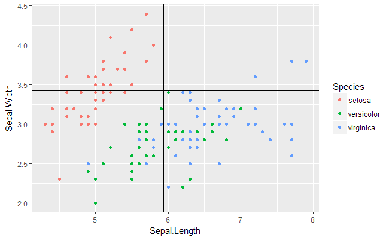

Two make this more usefull, we have to colour code the crosshair and visually put it back a little

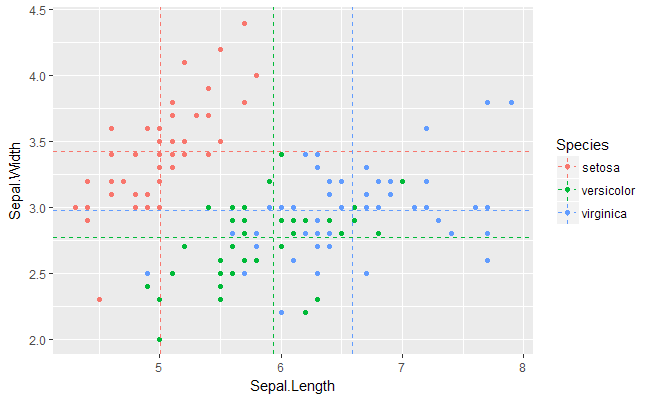

```r
plot1 +
  geom_hline(data = iris.summary, linetype=2,
             aes(yintercept = Sepal.Width,
                 col=Species)) +
  geom_vline(data=iris.summary,
             aes(xintercept = Sepal.Length, col=Species),
             linetype=2)
```

Further exercises:

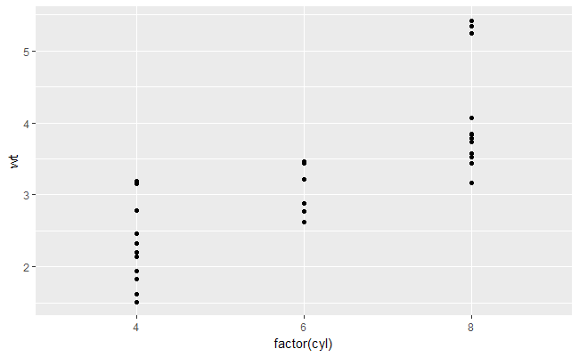

```r
ggplot(mtcars, aes(factor(cyl), wt)) +
  geom_point()
```

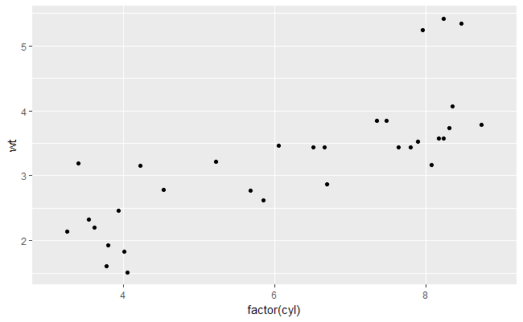

```r
# To conquer overplotting we specify the jitter
ggplot(mtcars, aes(factor(cyl), wt)) +
  geom_jitter()
```

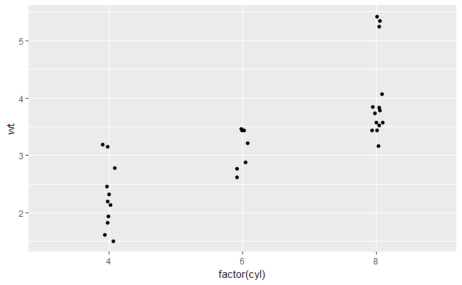

```r
# We Define the position to use jitter
posn.j <- position_jitter(widt=0.05)
ggplot(mtcars, aes(factor(cyl), wt)) +
  geom_point(position=posn.j)
```

### Barplots - Typical Use and Aesthetics

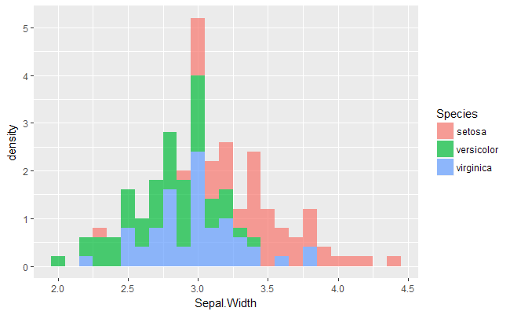

```r
ggplot(iris, aes(Sepal.Width, fill = Species)) +
  geom_histogram(aes(y = ..density..),binwidth = 0.1, alpha=0.7)
```

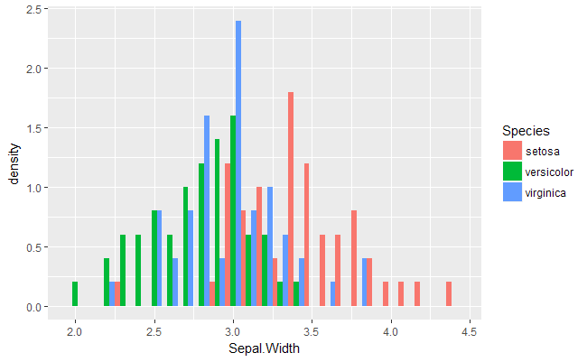

```r
ggplot(iris, aes(Sepal.Width, fill = Species)) +
  geom_histogram(aes(y = ..density..),binwidth = 0.1, position="dodge")
```

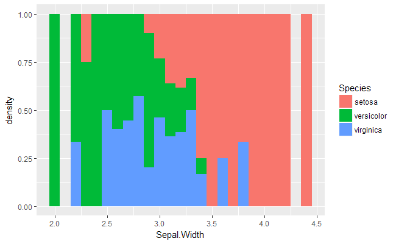

```r
ggplot(iris, aes(Sepal.Width, fill = Species)) +
  geom_histogram(aes(y = ..density..),binwidth = 0.1, position="fill")
```